# Kevin O’Brien

### Kevin O’Brien

#### About Me

- Agricultural Data Scientist based between the West of Ireland and London (UK)
- Was (what is now known) as a “Research Software Engineer” in a University.
- Former University Lecturer of Mathematics and Statistics.
  - Maths and Statistics Students (Teaching R, Matlab and Julia)
  - Health sciences, Life Sciences, Equine science, Sports Science, Food science, Biochemistry
  - **Important:** At no stage of my career was I affiliated with the MACSI research cluster.

### Biography

### Open Source Technology Communities

In recent years, I’ve been part of the organizing teams for several major PyData conferences, including PyData London 2025, PyData NYC 2024, and ongoing support for PyData Global. My contributions typically focus on social media strategy, corporate outreach, speaker recruitment, CFP review, and session chairing.

I also assisted with the organization of PyData Berlin 2025, specifically in retrieving social media assets and advising on best practices for outreach and engagement.

Earlier in my journey, I founded PyData Dublin / PyData Ireland, helping establish a vibrant local community. While I’ve since stepped back from day-to-day organizational duties, the initiative continues to thrive.

I served on the Board of Python Ireland, acting as Conference Lead for PyCon Ireland (2015–2019) and PyCon Limerick (2019–2020). Over the past decade, I’ve also been actively involved in the R and Julia communities, contributing to events, outreach, and cross-community collaboration.

#### notes

### What AI Says about Me

### What AI Says about Me

**Disclaimer - This is a mixture of truth and nonsense**

Kevin O’Brien is a prominent figure in the data science community in Dublin. He has a strong background in statistical computing and data visualization, with interests spanning R, Julia, Python, MATLAB, and big data analytics¹. Kevin has been a co-chair of the DublinR group, where he played a key role in organizing meetups and fostering a community for R users in Dublin¹.

In addition to his work with DublinR, Kevin is also associated with University College Dublin, where he specializes in bioinformatics³. His research contributions have been recognized with a notable h-index, reflecting his impact in the field³.

Would you like to know more about his work in bioinformatics or his contributions to the R community?

Source: Conversation with Copilot, 13/9/2024 (1) Kevin O’Brien - Dublin, Ireland | about.me. https://about.me/statslabdublin. (2) KEVIN O’BRIEN | University College Dublin | CUFinder. https://cufinder.io/professor/kevin-obrien-UzEUXlkAAAAJ. (3) Dublin R - Meetup. https://www.meetup.com/DublinR/.

Kevin Patrick O’Brien is a notable figure in the PyData community. He is known for his contributions to data visualization and data science. He has given talks at various PyData and Python-related conferences, including a presentation on “Data Visualization with ggplot” at PyCon Ireland.

O’Brien is recognized for his expertise in using Python for data analysis and visualization, and he actively participates in the community by sharing his knowledge and insights.

Source: Conversation with Copilot, 13/9/2024 (1) Python Ireland | #PyConIE Talks: Kevin O’Brien ’Data … - Facebook. https://www.facebook.com/groups/pythonie/posts/10154123747628465/. (2) PyData. https://pydata.org/. (3) PyData London 2024. https://pydata.org/london2024/. (4) undefined. http://buff.ly/1LiqhP8.

### Affiliations

#### Affiliations

- Why R? Foundation - Community Team lead & Webinars co-ordinator (on hiatus)
- JuliaCon 2023 - Social Media Chair (2017 to 2023)
- Python Ireland - **Former** Director & Conference Lead

### Research Software Engineering

#### Research Software Engineering

- Research software engineering is the use of software engineering practices in research applications.
- The term was proposed in a research paper in 2010 in response to an empirical survey on tools used for software development in research projects.
- It started to be used in United Kingdom in 2012, when it was needed to define the type of software development needed in research.
- This focuses on reproducibility, reusability, and accuracy of data analysis and applications created for research.

### Cynthia Longfield

### Madame Dragonfly

Cynthia Evelyn Longfield (1896–1991) was an Anglo-Irish entomologist and explorer, renowned for her expertise in dragonflies. Often referred to as “Madame Dragonfly,” she was the first woman to become a member of the Entomological Society¹².

Longfield’s passion for entomology took her on numerous expeditions around the world, including South America, Africa, and Southeast Asia. She collected and identified many new species of dragonflies and butterflies². Her book, *The Dragonflies of the British Isles*, published in 1937, became a standard reference in the field¹².

She also worked as a research associate at the Natural History Museum in London, where she was responsible for the dragonfly collection¹. Longfield’s contributions to entomology and her adventurous spirit made her a significant figure in the scientific community.

#### References

1. Cynthia Longfield - Wikipedia. https://en.wikipedia.org/wiki/Cynthia_Longfield.
2. CYNTHIA LONGFIELD / Entomologist, world traveller. https://www.herstory.ie/news/2019/5/22/cynthia-longfield-entomologist-world-traveller.
3. Cynthia Longfield facts for kids - Kids encyclopedia. https://kids.kiddle.co/Cynthia_Longfield.
4. Ireland’s Greatest Woman Inventor finalist - Cynthia Longfield, Madame …. https://www.siliconrepublic.com/science/irelands-greatest-woman-inventor-finalist-cynthia-longfield-madame-dragonfly.

# useR! Conference - Warsaw 2026

### useR! Conference

### useR! Conference - Warsaw 2026

useR! Conference - Warsaw 2026

The **useR! conference** is an annual event organized by volunteers from the R community and supported by the R Foundation. It showcases the latest applications and developments in R, a popular programming language for statistical computing and graphics. The conference features a variety of activities, including keynote speeches, technical talks, workshops, and poster sessions¹.

#### References

1. useR! | LF Events. https://events.linuxfoundation.org/user/.
2. 2026 Esri User Conference. https://uc2026.esri.com/flow/esri/24uc/eventportal/page/detailed-agenda.
3. useR! 2022. https://user2022.r-project.org/.
4. About - user2022.r-project.org. https://user2022.r-project.org/about/user/.

### Organizing Committee

## Organising Committee

- James Black
- Emily Ruff
- Linux Foundation Events Team

## Additional Support

We’d like to thank the R Consortium for their fiduciary oversight and support of the core compoments of useR! (e.g. this website theme, R User Groups globally, and R-ladies)

## Working groups

**Website**: James Black (Quarto theme by Ben Ubah working under an R Consortium Grant)

**Diversity & Inclusion**: Binod J. Bogati, Ozan Evkaya, Lydia Gibson

**Online experience**: Mayank Agrawal

**Social experience**: Robert Mueller, Moritz Lang

**Marketing**: Steven Kell, Kevin O’Brien

# useR! Conference - Durham (NC) 2025

### useR! Conference

The **useR! conference** is an annual event organized by volunteers from the R community and supported by the R Foundation. It showcases the latest applications and developments in R, a popular programming language for statistical computing and graphics. The conference features a variety of activities, including keynote speeches, technical talks, workshops, and poster sessions¹.

#### References

1. useR! | LF Events. https://events.linuxfoundation.org/user/.
2. 2024 Esri User Conference. https://uc2024.esri.com/flow/esri/24uc/eventportal/page/detailed-agenda.
3. useR! 2022. https://user2022.r-project.org/.
4. About - user2022.r-project.org. https://user2022.r-project.org/about/user/.

### Organizing Committee

## Organising Committee

- James Black
- Emily Ruff
- Linux Foundation Events Team

## Additional Support

We’d like to thank the R Consortium for their fiduciary oversight and support of the core compoments of useR! (e.g. this website theme, R User Groups globally, and R-ladies)

## Working groups

**Website**: James Black (Quarto theme by Ben Ubah working under an R Consortium Grant)

**Diversity & Inclusion**: Binod J. Bogati, Ozan Evkaya, Lydia Gibson

**Online experience**: Mayank Agrawal

**Social experience**: Robert Mueller, Moritz Lang

**Marketing**: Steven Kell, Kevin O’Brien

# PyData NYC Conference

### PyData NYC Conference 2024

#### PyData NYC Conference 2024

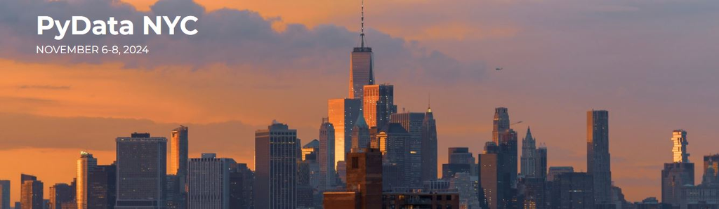

PyData NYC Conf 2024

The **PyData NYC conference** is an annual event that brings together an international community of data scientists, data engineers, and developers of data analysis tools. The conference focuses on sharing ideas, best practices, and emerging technologies in data management, processing, analytics, and visualization².

The event typically includes keynote sessions, talks, lightning talks, and tutorials. It’s a great opportunity for networking and learning from experts in the field. The next PyData NYC conference is scheduled for November 6-8, 2024³.

#### Programme

At PyData NYC, you’ll find a wide range of topics that cater to various interests within the data science and analytics community. Some popular topics typically covered include:

- **Machine Learning and AI**: Techniques, tools, and applications in various industries.
- **Data Visualization**: Best practices and tools for visualizing complex data.
- **Big Data**: Handling and processing large datasets efficiently.
- **Data Engineering**: Building and maintaining data pipelines and infrastructure.
- **Deep Learning**: Advances in neural networks and their applications.
- **Natural Language Processing (NLP)**: Techniques for processing and analyzing text data.
- **Data Ethics and Privacy**: Ensuring ethical use of data and protecting user privacy.
- **Open Source Tools**: Development and use of open-source software for data analysis.

These topics are often presented through a mix of keynote speeches, technical talks, hands-on tutorials, and panel discussions. Is there a particular topic you’re most interested in?

1. PyData NYC 2023. https://pydata.org/nyc2023/.
2. PyData NYC - Meetup. https://www.meetup.com/pydatanyc/.
3. PyData NYC - Home. https://nyc.pydata.org/.
4. Home | PyData NYC 2022. https://pydata.org/nyc2022/.
5. About - PyData NYC 2022. https://pydata.org/nyc2022/about/.

### Social Programme - Friday

#### Free Friday Nights @ The Whitney Museum

The Whitney Museum of American Art hosts **Free Friday Nights** every Friday from 5:00 PM to 10:00 PM¹². During this time, admission to the museum is free for all visitors. The event includes:

- **Access to exhibitions**: Explore the museum’s current exhibitions without any admission fee.
- **Special programming**: Enjoy various activities and events that may include talks, performances, and more.
- **Music**: Experience live or curated music to enhance your visit.
- **Stunning views**: Take in the beautiful views of the Statue of Liberty, Empire State Building, and more from the museum’s iconic terraces.

Though admission is free, tickets are required, and capacity is limited, so it’s recommended to reserve tickets in advance.

#### The High Line

The High Line is a unique public park in New York City, built on a historic elevated freight rail line on Manhattan’s West Side. It stretches for 1.45 miles (2.33 km) from Gansevoort Street in the Meatpacking District to 34th Street near the Javits Center1.

#### Walking to the Whitney

Here’s a step-by-step guide to walk from the Microsoft Conference Center at Times Square to the Whitney Museum of American Art, using the High Line:

1. **Start at the Microsoft Conference Center** located at 11 Times Square, 8th Avenue & 41st Street.
2. **Head southwest on 8th Avenue** towards 34th Street. This is about a 10-minute walk.
3. **Turn right onto 34th Street** and continue walking west until you reach the entrance to the High Line at 34th Street and 12th Avenue.
4. **Enter the High Line** and enjoy a scenic walk south. The High Line is an elevated park built on a historic freight rail line, offering great views of the city and the Hudson River.
5. **Continue walking south on the High Line** until you reach the Gansevoort Street exit. This is the southern end of the High Line, located in the Meatpacking District.
6. **Exit the High Line at Gansevoort Street** and head east towards Washington Street.
7. **Turn right onto Washington Street** and walk south for a short distance until you reach the Whitney Museum of American Art at 99 Gansevoort Street.

This route is approximately 2 miles and should take around 40-50 minutes, depending on your walking pace and how much time you spend enjoying the High Line.

#### Refences

1. Free Friday Nights | Whitney Museum of American Art. https://whitney.org/visit/free-friday-nights.
2. Free Friday Nights and Second Sundays - Whitney Museum. https://whitney.org/visit/free-days-and-nights.
3. Free and Discounted Admission | Whitney Museum of American Art. https://whitney.org/visit/free-admission.

### Algonquin Hotel

The Algonquin Hotel in New York is historically significant for several reasons:

1. **Literary and Cultural Hub**: The hotel is renowned for being the meeting place of the Algonquin Round Table, a group of influential writers, critics, and actors who gathered there for lunch and lively discussions during the 1920s³. This group included notable figures like Dorothy Parker, Robert Benchley, and Alexander Woollcott⁵.
2. **Architectural Significance**: Opened in 1902, the hotel features a blend of Renaissance Revival and Beaux-Arts architectural styles³. Its design includes intricate details such as rusticated limestone blocks and decorative terracotta elements³.
3. **Cultural Contributions**: The Algonquin has hosted numerous literary and theatrical notables throughout its history. It has been a significant venue for the arts, often frequented by actors, producers, and writers⁵.
4. **Traditions and Innovations**: The hotel’s first owner-manager, Frank Case, established many traditions, including an official hotel cat and discounts for struggling authors³. Case’s innovative management helped the hotel become a beloved institution in New York City⁴.
5. **Landmark Status**: The Algonquin Hotel is a designated New York City landmark, recognizing its historical and cultural importance³.

Have you ever visited or stayed at the Algonquin Hotel?

Source: Conversation with Copilot, 20/9/2024 (1) Algonquin Hotel - Wikipedia. https://en.wikipedia.org/wiki/Algonquin_Hotel. (2) The Algonquin Hotel - Dorothy Parker Society. https://dorothyparker.com/dorothy-parker-haunts/the-algonquin-hotel. (3) Historic Hotels of America. https://www.historichotels.org/us/hotels-resorts/the-algonquin-hotel-times-square-autograph-collection/history.php. (4) . https://bing.com/search?q=Algonquin+Hotel+New+York+historically+significant. (5) The Algonquin Hotel Times Square, Autograph Collection. https://www.algonquinhotel.com/. (6) Algonquin Hotel - The Historical Marker Database. https://www.hmdb.org/m.asp?m=146887. (7) en.wikipedia.org. https://en.wikipedia.org/wiki/Algonquin_Hotel.

# useR! Conference - Salzburg 2024

### useR! Conference

### useR! Conference - Salzburg 2024

useR! Conference - Salzburg 2024

The **useR! conference** is an annual event organized by volunteers from the R community and supported by the R Foundation. It showcases the latest applications and developments in R, a popular programming language for statistical computing and graphics. The conference features a variety of activities, including keynote speeches, technical talks, workshops, and poster sessions¹.

The next useR! conference will be held from **July 8th to 11th, 2024**, in **Salzburg, Austria**, with virtual participation options available¹. It’s a great opportunity for R users, developers, data scientists, and statisticians from academia and industry to network, share knowledge, and learn about the latest advancements in R.

#### References

1. useR! | LF Events. https://events.linuxfoundation.org/user/.
2. 2024 Esri User Conference. https://uc2024.esri.com/flow/esri/24uc/eventportal/page/detailed-agenda.
3. useR! 2022. https://user2022.r-project.org/.
4. About - user2022.r-project.org. https://user2022.r-project.org/about/user/.

### Organizing Committee

## Organising Committee

- James Black
- Emily Ruff
- Linux Foundation Events Team

## Additional Support

We’d like to thank the R Consortium for their fiduciary oversight and support of the core compoments of useR! (e.g. this website theme, R User Groups globally, and R-ladies)

## Working groups

**Website**: James Black (Quarto theme by Ben Ubah working under an R Consortium Grant)

**Diversity & Inclusion**: Binod J. Bogati, Ozan Evkaya, Lydia Gibson

**Online experience**: Mayank Agrawal

**Social experience**: Robert Mueller, Moritz Lang

**Marketing**: Steven Kell, Kevin O’Brien

# JuliaCon

### JuliaCon

### JuliaCon

[figure not shown]

JuliaCon

JuliaCon is the largest annual conference dedicated to the Julia programming language. It brings together developers, researchers, and enthusiasts from around the world to share knowledge, present research, and discuss advancements in Julia. The event features a variety of activities, including technical talks, workshops, posters, and hackathons¹.

####References

1. JuliaCon 2024. https://juliacon.org/2024/.
2. JuliaCon 2024: Registration and Ticketing. https://juliacon.org/2024/tickets/.
3. About the Conference - JuliaCon 2023. https://live.juliacon.org/about.
4. JuliaCon 2019, Baltimore, MD, USA. https://juliacon.org/2019/.

### JuliaCon 2021 Virtual Conference

JuliaCon 2021 was held virtually from **July 28th to 30th, 2021**¹. The conference featured a wide range of activities, including keynote speeches, technical talks, workshops, and poster sessions. Some notable keynote speakers included William Kahan, Jan Vitek, and Xiaoye (Sherry) Li¹.

The event was accessible online, allowing participants from around the world to join and engage with the Julia community. All the recorded talks from the conference are available on YouTube, providing a valuable resource for those who couldn’t attend live¹.

Are you interested in any specific topics or talks from JuliaCon 2021?

Source: Conversation with Copilot, 14/9/2024 (1) JuliaCon 2021 & JuMP-dev, Everywhere on Earth. https://juliacon.org/2021/. (2) JuliaCon 2021. https://julialang.org/juliacon/. (3) Save the date: JuliaCon 2021 - Announcements - Julia Programming Language. https://discourse.julialang.org/t/save-the-date-juliacon-2021/51940. (4) undefined. https://juliacon.org/2021/tickets/. (5) undefined. https://live.juliacon.org. (6) undefined. https://live.juliacon.org/discord/join. (7) undefined. https://pretalx.com/juliacon2021/schedule/. (8) undefined. https://juliacon.org/2021/posters/. (9) undefined. https://juliacon.org/2021/experiences/. (10) undefined. https://www.eventbrite.com/x/137139721599/. (11) undefined. https://www.bonfire.com/store/the-julia-language/. (12) undefined. https://juliacon.org/2021/workshops/.

JuliaCon 2021 saw a record-breaking attendance with over **20,000 registrations** and more than **43,000 unique YouTube viewers** during the conference³. This made it the largest JuliaCon event to date, reflecting the growing interest and engagement in the Julia programming community.

Are you interested in any specific talks or topics from the conference?

Source: Conversation with Copilot, 14/9/2024 (1) JuliaCon 2021 Highlights. https://bing.com/search?q=JuliaCon+2021+attendance. (2) JuliaCon 2021 & JuMP-dev, Everywhere on Earth. https://juliacon.org/2021/. (3) JuliaCon 2021. https://julialang.org/juliacon/. (4) JuliaCon 2021 Highlights. https://julialang.org/blog/2021/08/juliacon-highlights/. (5) JuliaCon 2021, the largest Julia Programming event in history. https://julialang.org/blog/2021/07/juliacon2021/. (6) undefined. https://juliacon.org/2021/tickets/. (7) undefined. https://live.juliacon.org. (8) undefined. https://live.juliacon.org/discord/join. (9) undefined. https://pretalx.com/juliacon2021/schedule/. (10) undefined. https://juliacon.org/2021/posters/. (11) undefined. https://juliacon.org/2021/experiences/. (12) undefined. https://www.eventbrite.com/x/137139721599/. (13) undefined. https://www.bonfire.com/store/the-julia-language/. (14) undefined. https://juliacon.org/2021/workshops/.

### Juliacon Local

**JuliaCon Local Eindhoven 2023** was a one-day conference held on **December 1, 2023**, at the High Tech Campus Conference Center in Eindhoven, Netherlands¹². The event was co-hosted with PyData Eindhoven 2023, creating a unique opportunity for cross-pollination between the Julia and Python communities¹.

The conference featured a full day of talks, workshops, and networking sessions, covering a wide range of topics related to the Julia programming language². Highlights included a Pluto Workshop held the day before the main event, focusing on reactive and reproducible notebooks for Julia¹.

The event also emphasized inclusivity, offering diversity scholarships to individuals from underrepresented groups¹. Overall, it was a vibrant gathering for Julia enthusiasts to learn, share, and connect.

Are you interested in any specific topics or sessions from JuliaCon Local Eindhoven 2023?

Source: Conversation with Copilot, 14/9/2024 (1) JuliaCon Local Eindhoven 2023. https://juliacon.org/local/eindhoven2023/. (2) JuliaCon Local Eindhoven 2023 Program. https://juliacon.org/local/eindhoven2023/program/. (3) Experience JuliaCon Local - Eindhoven 2023 - info.juliahub.com. https://info.juliahub.com/blog/juliacon-local-eindhoven-2023. (4) JuliaCon 2023. https://juliacon.org/2023/.

# PyData Global 2022

### PyData Global

#### PyData Global

PyData Global 2022 Conference is taking place online between Thurs 1st and Sat 3rd December 2022. Join PyData for our third year hosting this event virtually bringing together PyData Chapters, community members, and attendees from all over the world together for an unforgettable PyData Conference.

To find out more, go to our conference website: www.pydata.org/global2022

#### Call For Proposals

The CFP is still open until September 12th, 2022.

We welcome attendees with wide varieties of experiences, expertise, and backgrounds to create a diverse and compelling learning opportunity. Users, contributors, and newcomers can share experiences and learn from one another to solve hard problems and grow a stronger community. nAs well are regular presentations, Workshops and Lightning Talks are also welcome.

Presentations will be given live with opportunities for questions and answers to facilitate a more engaging experience and a deeper discussion. Presentations will come in a variety of formats, such as workshops, talks, and panel discussions to create diverse learning experiences.

Following each session, a recording will be posted to attendees for continued viewing. At the conclusion of the Summit, all presentations will be posted on YouTube.

#### Pay What You Can

Tickets are currently on sale and once again we’ll be using a pay-what-you-can pricing model to maximize the number of community members able to participate in this world-class programming.

#### Talks, Tutorials & Keynotes - Something for Everyone

At PyData Global 2021, there was over 150 presentations this year including “Wounds Over Time - Tracking Wound Healing via 3D Models”, “Document your scientific project with Markdown, Sphinx, and Read the Docs”, “NLP and Hate speech: Why does it matter and what can we do?”. Keynote addresses were be given by Naomi Ceder and David Beazley

#### Keep In Touch

To stay up-to-date on all conference announcements:

- Follow the *PyData Global* company page on LinkedIn: [PyData Global](https://www.linkedin.com/company/74716291)
- Follow [PyData](http://www.twitter.com/pydata) on Twitter

# Why R? Limerick 2020

### Why R? @ Career Zoo Limerick 2020

[figure not shown]

#### Why-R? Limerick

- Date: Saturday 1st February 2020
- Location: Thomond Park Stadium, Cratloe Road, Limerick.
- Times: 10.00am to 16:30pm approx
- Career Zoo Limerick’s [Website](https://www.careerzoo.ie/limerick/)
- Why R? Limerick’s [Website](https://www.careerzoo.ie/limerick/why-r-mini-conference.html)

##### Tickets

- Admission is free, but attendees must have registered for Career Zoo.

### Tickets

##### Tickets

- Tickets can be ontained from [Career Zoo’s Eventbrite Page](https://www.eventbrite.ie/e/career-zoo-presents-tech-on-the-wild-atlantic-way-2020-tickets-77292514993#tickets)
- Tickets are free, but you must register for the event in advance.
- You should register for both Career Zoo and Why R?
- Please note that there are a limited number of tickets for the WhyR? event.

### Schedule

### Schedule

| Time | Talk |
| --- | --- |
| 10:00-10:30 | **Morning Session 1 (Munster Suite)** What makes a good (fantasy) football manager? Presented by [Joey O’Brien](https://twitter.com/obrienj_) |
| 10:30-11:00 | **Morning Session 2 (Munster Suite)** Using R-Shiny to Teach Quantitative Research Methods Presented by [Dr. Brendan Halpin (UL Sociology)](https://twitter.com/BrendanTHalpin) |
|  | (*Break*) |
| 11:20-11:50 | **CAREER ZOO COMMUNITY KEYNOTE @ Main stage** [Dr. Norah Patten](https://twitter.com/SpaceNorah) Astronaut candidate with Project PoSSUM (Polar Suborbital Science in the Upper Mesosphere) (*N.B. This … |
|  | (*Pause*) |
| 12:00-12:30 | **Morning Session 3 (Munster Suite)** ETL with R: a quantitative finance application Davide Magno |
| 12:30-13:00 | **Morning Session 4 (Munster Suite)** R - a Disruptive Force in Official Statistics Sorcha O’Callaghan Central Statistics Office, Cork www.cso.ie |
|  | (*Pause*) |
| 13:10-13:40 | **CAREER ZOO COMMUNITY KEYNOTE @ Main stage** Helping beekeepers to reduce honeybee losses & increase hive productivity with IOT technology. Dr Fiona Edwards Murphy, CEO and Co-founder of [ApisProtect… |
|  | (*Break*) |
| 14.10 - 14:40 | **Afternoon Session 1 (Munster Suite)** Knime with R Presented by [Paolo Tamagnini](https://twitter.com/paolotamag) |
| 14.40 - 15:10 | **Afternoon Session 2 (Munster Suite)** Data Optimisation Networks Gaurav Pahuja (Finalist in the Student Data Scientist of the Year category of the [DatSci Awards 2019](https://www.datsciawards.com/f… |
|  | (*Pause*) |
| 15:20-15:50 | **CAREER ZOO COMMUNITY KEYNOTE @ Main stage** [Abeba Birhane](https://twitter.com/Abebab) - Award winning PHD Student on ethics in AI (*N.B. This is not an R-specific talk*) |
|  | (*Pause*) |
| 16:00-16:30 | **Afternoon Session 3 (Munster Suite)** Visualizing Trends in the Loudness of Popular Music Presented by [David Curran](https://twitter.com/iamreddave) |

### Abstracts

#### Using R for Stylometry

**Who really wrote Shakespeare? A quick introduction to using R for stylometry.**

This workshop will demo the stylo package in R, conducting stylometric analyses of works by Shakespeare and some of his contemporaries.

The workshop will focus on the most important functions in stylo covering both supervised and unsupervised learning methods for authorship attribution.

**Presenter: [Rory Quinn](https://twitter.com/RoryJosephQuinn)**

Bio: I am a data science enthusiast who enjoys learning new tools and methodologies for extracting useful insight from data. I particularly like using R for its extensibility and great package ecosystem.

**Time and Location**

- The workshop takes place on Saturday 1st February at Thomond Park.
- The workshop will take place on Morning Session (11:00 to 12:00) in a workshop room at Career Zoo.
- The venue is ordinarily a corporate box suite, and has a capacity of 12 people.

**Requirement**

- Please bring a fully charged laptop with a recent version of R installed.

**Registration**

- To register, visit the [career zoo eventbrite site](https://www.eventbrite.ie/e/career-zoo-presents-tech-on-the-wild-atlantic-way-2020-tickets-77292514993#tickets) and select a general admission and a ticket for this workshop.

#### Data Science Learnathon with KNIME

**What is a Learnathon?**

It’s between a hackathon and a workshop. It’s like a workshop because we’ll learn more about the data science cycle - data access, data blending, data preparation, model training, optimization, testing, and deployment. It’s like a hackathon because we’ll work in groups to hack a workflow-based solution to guided exercises.

Full Details can be found on the [Career Zoo Website](https://www.careerzoo.ie/limerick/data-science-learnathon.html)

**About the Presenter**

Paolo Tamagnini is a data scientist at KNIME, holds a master’s degree in data science from Sapienza University of Rome and has research experience from NYU in data visualization techniques for machine learning interpretability. Follow Paolo on LinkedIn

**Requirements**

- Please bring your own laptop, ideally pre-installed with the latest version of KNIME Analytics Platform.
- Check the Career Zoo Websit for more details.

**Registration**

- To register, visit the [career zoo eventbrite site](https://www.eventbrite.ie/e/career-zoo-presents-tech-on-the-wild-atlantic-way-2020-tickets-77292514993#tickets) and select a general admission and a ticket for this workshop.

#### Machine Learning With Julia

**THIS EVENT IS NOW SOLD OUT**

Join Julia Computing’s [Avik Sengupta (VP Engineering)](https://twitter.com/aviksengupta) who is leading a workshop on ‘Machine Learning with Julia’.

Julia is the fastest high-performance open source computing language for data, analytics, algorithmic trading, machine learning, artificial intelligence, and other scientific and numeric computing applications. Julia solves the two language problem by combining the ease of use of Python and R with the speed of C++.

Julia works with GPUs, TPUs, multithreading and parallel processing to deliver seamless unlimited scalability from a single CPU to thousands of nodes, cores and threads in the public or private cloud. Julia has run at petascale on 9,300 Knights Landing (KNL) nodes with 650,000 cores and 1.3 million threads to analyze over 56 terabytes of data using Cori, one of the ten largest and most powerful supercomputers in the world.

Julia has been downloaded more than 12 million times and is used at more than 1,500 universities. Julia co-creators are the winners of the 2019 James H. Wilkinson Prize for Numerical Software and the 2019 Sidney Fernbach Award.

Julia Computing was founded in 2015 by all the creators of Julia to provide products including JuliaTeam, JuliaSure and JuliaRun to businesses and researchers using Julia.

**Links**

- [The Julia Language](https://julialang.org/) - The main portal for the Julia language
- JuliaCon 2020, Lisbon - Julia’s international conference
- Julia Computing - Professional services for Julia

#### Machine Learning For Coders

**Machine Learning For Coders**

Presenter: Iain Keaney ( skellig.ai )

**Abstract**

- Machine Learning (ML) is no longer ring fenced to researchers and data scientists.
- New high-level APIs are driving the democratisation of ML applications and enabling programmers to build and implement ML solutions in their own work.
- This workshop describes how these APIs work and why they sometimes perform better than even state-of-the-art solutions.

**Time and Location**

- The workshop takes place on Saturday 1st February at Thomond Park.
- The workshop will take place on Morning Session (11:00 to 13:00) in a workshop room at Career Zoo.
- The venue is ordinarily a corporate box suite, and has a capacity of 12 people.

**Requirement**

- Please bring a fully charged laptop.

**About the Presenter**

As a creative engineer, I love to build new things. I’ve previously worked on a computer vision start-up, developing a consumer solution for mobile 3D scanning. My PhD focused on an application of artificial intelligence in offshore engineering.

In 2017 I was named in The Sunday Business Post’s 30 Under 30 Most Interesting People in Irish Tech.

**Registration**

- To register, visit the [career zoo eventbrite site](https://www.eventbrite.ie/e/career-zoo-presents-tech-on-the-wild-atlantic-way-2020-tickets-77292514993#tickets) and select a general admission and a ticket for this workshop.

#### Git and GitHub: A hands-on workshop

Venue: Workshop Room

Workshop (14:00 - 16:00)

Presented by Chidubem Iddianozie (UCD /Github)

**Abstract**

Turbo-Charging your technical dexterity using Git and GitHub: A hands-on workshop.

- This workshop covers all that is needed to integrate git into your daily development life using GitHub.
- We will begin with a discussion of what git is and how it works.
- Then a hands-on session, where we will run through multiple templated practical scenarios using Git commands.
- Lastly, we will wrap up by discussing other free offerings such as hosting websites using Pages.

**Requirement**

- A laptop.

**Registration** * To register, visit the [career zoo eventbrite site](https://www.eventbrite.ie/e/career-zoo-presents-tech-on-the-wild-atlantic-way-2020-tickets-77292514993#tickets) and select a general admission and a ticket for this workshop.

# PyCon Ireland

### PyCon Ireland

**PyCon Ireland** is an annual conference organized by Python Ireland, the Irish organization representing Python users. The event brings together Python enthusiasts, developers, and professionals to share knowledge, network, and discuss the latest advancements in Python programming.

#### Links

1. PyCon - Python Ireland. https://pycon.ie/.

### PyCon Ireland 2024

**PyCon Ireland 2024** will take place in Dublin on **November 16th and 17th**¹. The conference will feature a dynamic, multi-track program on Saturday, followed by hands-on workshops on Sunday. Attendees can look forward to a diverse range of talks and workshops covering topics from scripting and machine learning to web development and cloud deployments¹.

The event is known for its warm and friendly atmosphere, making it a great opportunity for both newcomers and seasoned Python veterans to connect and learn¹.

#### Links

1. PyCon - Python Ireland. https://pycon.ie/.
2. PyCon Ireland 2024 - Python. http://python.ie/pycon-2024/.
3. undefined. https://sessionize.com/pycon-ireland-2024.

# Why R? Foundation

### Why R? Foundation

#### Why R? Foundation

- The Why R? webinar series took place between April 2020? And May 2021. In total, there were more than 50 webinars encompassing a wide variety of topics relation to the R programming language.
- In addition to the webinar series, there were two online conferences that took place in December 2020 and December 2021.

# PyCon - Everybody Pays Principle

### PyData Global

#### PREAMBLE

There’s been some recent discussion about DjangoCon(.eu | .us) and whether or not speakers should have to pay for admission as well - see Chris Wanstrath’s (of Github) tweets (here and here) and this Convore thread for examples. Obviously, as PyCon is the “big dog” so to speak for Python conferences, everyone looks to “us” for a model to work from, or how we manage things. I’ve seen a lot of poop slung towards the DjangoCon organizers, mainly due to a lack of knowing “why” certain policies (such as “Everyone Pays”) exist for DjangoCon, PyCon, and other conferences.

As co-chair and program committee chair last year, and program committee chair the year before, and now chair for the next two years - I figured it might be good to take a moment to explain the rationale behind PyCon’s approach - as well as some statistics about the budget. I’m not going to state that this policy is perfect; nor that it won’t be changed; I also will not release the budget publicly - I don’t think giving everyone a spreadsheet without the context of the hundreds of man hours of work that go into it is useful, at all.

Important Note: PyCon is organized and managed by the Python Software Foundation - this means that, as part of being a 501c3 charity, some of the financials from past PyCon is available as part of publicly accessible financial documents of the foundation. You can find those on the PSF’s site.

The same reasoning may not apply to a conference that is organized by a commercial entity or is done for profit. OSCON is a commercial conference, so having speakers get in free is generally expected. DjangoCon.us is in the middle - it is organized for profit by a commercial entity, but it also contributes heavily back to the Django Software Foundation. DjangoCon.eu is managed differently as well.

#### POLICY AND FINANCIAL AID

First, what is the “policy” - well, first, it’s not a policy per-se; it’s part policy, and part tradition. The policy is “Everyone pays for a ticket” - attendees, tutorial presenters, organizers (meaning: all volunteers, including the chair) and sponsors - everyone pays their way. Yes, this means Van and myself both paid for our own tickets to attend. Everyone is treated as equal - sponsors get free admissions as part of conference sponsorship packages, and keynote speakers may be provided with either compensation or admission depending on the negotiated deal (some keynote speakers cost money, for example).

Now; an interesting aspect of this is that PyCon, as a conference, offers a very generous financial aid program - this means that some attendees, speakers, tutorial presenters, etc have some, or in rare cases, all of their expenses such as flight, hotel and admission provided to them from the PyCon budget. PyCon goes out of it’s way to encourage people to apply for financial aid - even if we can’t cover all of your expenses, we will give you free admission based on need. The FA application process is simple, and straightforward. It’s also very liberal - the only caveat is that speakers at the conference “get bumped to the top” of the applications so that we don’t lose a good talk because of financial need. We also don’t ban anyone from applying (for example, I needed assistance in 2010 even as the PC chair).

We use the FA budget to not only help the “normal” attendees of the conference, we also keep an eye towards diversity - for example in 2010 we had a specific grant program (funded by Google) for women to attend PyCon - which they did in amazing numbers! We also try to help more people with less money than less people with more money - we want to spread assistance out as much as possible. This is why FA requires room-sharing at the conference hotel, this is why we may only cover part of a given applicant’s costs - we want to help more people.

As you can guess - since financial aid is a part of the budget, we allocate a set amount of money to this - but, without a solid budget (meaning, admission ticket sales, sponsorships, etc) we can’t have it - it’s actually a dice roll. We can guess at how much FA we can carve out of the budget at the start of the process, and we will award that amount - but that means if we have low attendance, don’t book enough rooms, or our catering costs spike, or lack sponsors, the conference can lose not insignificant amounts of money helping people. The rub being, you don’t know for sure if this will happen until the conference actually happens.

So, how does “everybody pays” play into this? In two ways. First, it helps hedge our risk, institutionally speaking. PyCon had a good/bad year in 2009 - good for the attendees, but horrendously bad financially. We made various commitments in 2008 just as the markets were peaking, and we lost a lot of money when everything went south. Since then, it has been our budget policy to make sure that our revenues will cover our hard costs even if there is a 15% dip in attendance and a 35% dip in sponsorship.

Second, you may have guessed that the “everybody pays” policy allows us to pad the financial aid budget. This has the direct benefit of bringing more people to the conference, increasing the diversity of people attending, getting a larger proportion of the community together, etc.

I’m happy to say, that on most years, we very happily break our financial aid budget - meaning, if we have a positive outlook, we will gladly overspend on financial aid and take less “profit” for the conference. The point of the conference is the community, it’s not about the conference! We help the community as much as we can by helping to cover the costs of people who would not otherwise be able to attend.

#### HISTORY AND TRADITION

It is my understanding that the policy/tradition has as much to do with financials as it does with “the feel”. No one is treated specially, we - meaning the community - put together the conference, we are taking the financial risk that comes with it. We are in it together, and that means “everyone helps, and everyone pays” - it is the most equitable solution that helps us maintain fairness and the flavor/feel of the conference. When you realize that even Guido has to buy a ticket (even if it was paid for by Google) or that Van Lindberg had to buy one - it suddenly makes you realize that all of us truly believe in the spirit of “we are all in this”.

Speakers; as a an additional guideline, while always paying for a ticket; always pay at the discounted early bird rate no matter when they register. So yes, we do discount them, but no more than anyone else who registers within the early bird window.

As an aside, the “everybody helps” is also part of what makes PyCon special. When people come to other conferences, they frequently come expecting to be coddled and catered to. When people come to PyCon, we hope they come expecting to contribute. Having everybody contributing is at the core of the best parts of PyCon - from stuffing bags, to lightning talks, to the wonderful Testing in Python BOF.

#### HARD COSTS, STATS AND RISK

So what makes up a PyCon budget? Well - Van covered some of it in his wonderful “Behind the Scenes” post for PyCon 2011 - but in more detailed terms of percentages of the total costs for the budget:

Catering (Food, beverages): 54% Networking: 5% Audio/Visual and Video Recording: 13% Payments to Tutorial Instructors: 6% Misc/PR/Sponsors and Administration: 16% Swag: 2% Financial Aid: 4%

We could forgo feeding people - but with a conference that runs from 8am to 6pm for 5 days, that would suck - and people needing to leave to get food would be disruptive and ruin the flow. We could forgo recording the videos. We could do a lot of things to cut back and lower the budget numbers so we could give more away (such as comp’ing speaker tickets), but that doesn’t make the risk and costs from the hotel go away.

Average Revenue per attendee: ~$300 Average Cost per attendee: ~$465

In total - these costs (for 2011) came to well over 600,000$ - that’s right. Over half a million dollars in hard costs for a conference of 1,380 Pythonistas. Much of the payments, guarantees, deposits, etc have to be put down up front of the actual conference with no guarantee that we will make our sponsorship or attendee numbers. That means, in the case of PyCon - the Python Software Foundation fronts potentially hundreds of thousands of dollars in payments and risk. We also expect these to climb with the move of the conference to Santa Clara.

Conferences are unknowns - you put up a lot of time, energy and money - lots of money - and you hope you hit certain numbers. For example, you make a contract with the hotel that says “we will have X number of people book X number of rooms nights” - if you don’t meet those numbers? The hotel penalizes you a stunning amount of money. You make a contact for catering - saying that you will serve X number of meals - and if you don’t hit that? You get penalized. You put a lot of faith in making numbers on:

Sponsors - without corporate sponsors, we simply could not exist (at this scale), period. Attendee Numbers - You expect X number of attendees, broken up into “corporate, individual and Y” rates - corporate rate tickets are where you make the bulk of registration rates. Hotel Rooms - if you don’t hit your contracted numbers, you will take a bath Do you know what happens if, for some reason - say an economic downturn - you don’t make those numbers? Your conference loses over $230,000, possibly more. That 230k number? Right around the amount PyCon 2009 lost, representing a massive financial loss for the Python Software Foundation. Yes, you try to mitigate the risks by careful planning - if you’re lucky, you get some insurance to cover some of the potential losses. PyCon is actually really lucky in all of this - we’ve grown enough that we get to leverage economies of scale with the contracts we deal with. Small conferences? Not so much - they get harder in the face of failure, and they don’t have the bargaining power we have..

It’s a delicate balancing act, requiring careful planning and a lot of work to drive attendance and sponsorship - negotiations with Hotels, Catering, Unions, are all things that have to go right in order to make a conference that even stands a chance of not losing you massive amounts of money. In the case of PyCon - a massive loss of money (such as 2009) could cause the foundation to go bankrupt and dissolve. As it is, the foundation, already spartan in spending cut back even further to protect itself which represents a net negative for the Python Community.

#### WHERE DOES THE PROFIT GO?

Alright - I’ve outlined the philosophy, the scale and the risk. Now, you’re probably asking where, if we have it, does any profit from the conference go? Easy - straight back into the community.

Whatever profit - really, money left over, goes to cover the initial costs/risks for PyCon the next year, and the years after - it also goes to the Python Software Foundation that in turn, reinvests that money into the community (see the foundation blog).

Having a healthy positive margin also means we can increase things such as the financial aid budget for the next year, allowing even more Python developers to attend.

Why not run a budget that aims for 0$ +/-?!

Because, that is simply insane - you can aim for minimal profit by reinvesting into things such as financial aid, or other perks for the attendees but only after you have guaranteed you’re going to make your numbers - see the issue? At best, you budget is a highly refined series of educated guesses. At worst? Someone goes bankrupt - at smaller conferences such as DjangoCon.eu, where some costs and contracts are secured by an individual and their credit card?

That person goes broke, because the entities you signed contracts with will get their money.

So, you never, ever aim for a loss, but you also don’t aim for extracting “maximum value” from conference attendees. You aim, you plan, and you hope to provide the best value and experience to attendees and sponsors - you do this through a lot of hard work and sweat. You make sure attendees walk away raving about the conference, you make sure you generate the maximum return on investment for the community.

#### IN CLOSING

Historically, PyCon has never been aimed at “extracting money” from the community - it could be run a lot more profitably. We could increase ticket rates, reduce FA and walk around in Nascar-esque suits with sponsor logos on them - there’s lots of things that could be done to make PyCon a massive profit center for the PSF. We don’t though - why? Because, that defeats the purpose of a community conference, put together by and for the community.

We take what money we end up with and we sponsor the sprints at PyCon itself, we hold the language and virtual machine summits. The PSF reinvests it into the Python community as a whole (see the sprints project, for example, or the 10,000$ check we gave to PyPy). The money is given out in the forms of developer grants, holding sprints, providing sponsorship to smaller Python conferences all over the world, outreach and education initiatives, etc. No one gets a shiny new car or anything - money that comes from the community conference goes back into the community. You can see how much goes where if you peruse the PSF resolutions page.

PyCon is beginning to also outstrip the ability for a small group of volunteers to put together - more and more we’ve had to bring on commercial entities (whom we have to pay) to assist in organizing or doing specific things (such as registration, or website development). I fully expect PyCon 2012/2013 to quickly hit the attendance cap meaning we’re going to have more scaling issues and higher costs - this is a fundamentally good thing - PyCon, it is felt, can sustain it’s current feel and quality up to a maximum of 1500-2000 attendees.

We do not have the intention of raising that cap.

Instead, we - as the foundation - intend on encouraging smaller more regional conferences such as PyOhio to grow - PyCon will continue to be the “big dog” so to speak - but it being the big dog will allow us to further cultivate and pollenate the entire Python community and ecosystem.

Given all of that - as the PyCon chair for the next two years - and being relatively comfortable that we will again, put on a highly successful conference - I am exploring the idea of steeply discounting the cost of tickets for speakers. I feel that not only is the conference viable once again, but that the speakers do help make the conference what it is - last year we had over 200 talk and tutorial submissions. All of those speakers submitted talks knowing that they would have to pay for a ticket to attend - but given the positive outlook, I’m comfortable in thinking that we will be able to provide accepted speakers with a discount to thank them for their talk.

It’s all about community, and reinvesting in it in the right places, at the right times, and managing your risk. The risks putting on a conference - even a small one (especially a small one) are massive, but the returns - especially when you’re standing on a stage in front of 1380 fellow Python hackers handing a big cardboard check to a fantastic project?

Well, the returns are well worth it.

# Linkedin Tag Followership

### Linkedin Tag Followership

### Linkedin Tag Followership

| Tag | Date | Followers |
| --- | --- | --- |
| softwareengineer | 2021-06-21 | 97542 |
| spatialsurvey | 2021-06-21 | 0 |
| statisticalanalysis | 2021-06-21 | 628 |
| statistician | 2021-06-21 | 876 |
| survey | 2021-06-21 | 7325 |
| systematic | 2021-06-21 | 87 |
| systemsbiology | 2021-06-21 | 191 |
| tableausoftware | 2021-06-21 | 4423 |
| tensorflowjs | 2021-06-21 | 145 |
| tensorflowlite | 2021-06-21 | 54 |

[output cut: 641 more lines]

#### Details

- Tag by most recent recording date

# R Talks

### Working With Documents

### Working With Documents

- Presented at the London R Meetup in June 2022
- Working With Documents

### Older Talks

#### “Probability: Pitfalls, Paradoxes”

- Versions in various programming languages to be revised in 2024
- Monty Hall Problem, The Monte Carlo Gambler’s Ruin of 1913, The Canadian Lottery Winner.
- Implementation of several topics discussed in “The Drunkard’s Walk” s

#### Diagnostics and Model Appraisal for R

- Model Diagnostics for Linear Models and GLMs
- Graphical Procedures i.e. QQ plots, In-built model diagnostic plots, Radio Plots
- Cooks’ Distance, Mahalanobis Distances, DFFITS, DFBETAs

# Jameson Dublin International Film Festival

### Jameson Dublin International_Film Festival

### Audience Development at JDIFF

Beginning as a full time volunteer worker in 2004, the second iteration of JDIFF, I worked on the Film Festival on each iteration up to 2012. In the later years I worked in the nascent “Audience Development” section of the festival.

### Jameson Dublin International_Film Festival

The **Jameson Dublin International Film Festival (JDIFF)** was an annual film festival held in Dublin, Ireland, from 2003 to 2016. Sponsored by Jameson Irish Whiskey, the festival showcased a diverse selection of Irish and international films, including features, documentaries, and shorts¹.

JDIFF was known for its star-studded premieres, exclusive screenings, and events that celebrated the art and craft of filmmaking. It also featured Q&A sessions, industry masterclasses, and community celebrations². In 2016, the sponsorship by Jameson ended, and the festival was rebranded as the Audi Dublin International Film Festival (ADIFF) with Audi as the new sponsor¹.

The festival continues today as the Dublin International Film Festival (DIFF), maintaining its reputation as a world-class destination for film enthusiasts².

#### References

1. Dublin International Film Festival - Wikipedia. https://en.wikipedia.org/wiki/Dublin_International_Film_Festival.
2. Dublin International Film Festival. https://www.diff.ie/.
3. en.wikipedia.org. https://en.wikipedia.org/wiki/Dublin_International_Film_Festival.

# Audience development

### Audience development

### Audience Development

Audience development in the context of cultural and artistic festivals refers to the strategic efforts made by an organization to attract, engage, and retain a diverse and growing audience. This involves a variety of activities and approaches aimed at broadening the reach and impact of the festival. Here are some key aspects:

1. **Understanding the Audience**: This involves researching and analyzing the demographics, preferences, and behaviors of current and potential audiences. Understanding who the audience is and what they want helps in tailoring the festival’s offerings to meet their needs¹.
2. **Marketing and Promotion**: Effective marketing strategies are crucial for audience development. This includes using traditional media, social media, partnerships, and other channels to promote the festival and attract a wider audience².
3. **Programming and Content**: Curating a diverse and engaging program that appeals to different segments of the audience is essential. This might include a mix of performances, workshops, exhibitions, and other activities that cater to various interests and age groups³.
4. **Accessibility and Inclusivity**: Ensuring that the festival is accessible to people from different backgrounds, including those with disabilities, and creating an inclusive environment where everyone feels welcome².
5. **Community Engagement**: Building relationships with local communities and involving them in the festival can help in creating a loyal audience base. This might include community outreach programs, collaborations with local artists, and participatory events³.
6. **Feedback and Evaluation**: Collecting feedback from attendees and evaluating the success of different initiatives helps in refining audience development strategies. This continuous improvement process ensures that the festival remains relevant and appealing².

By focusing on these areas, cultural and artistic festivals can develop a sustainable audience base, ensuring their long-term success and impact.

#### References

1. ATELIER FOR FESTIVAL MANAGERS TOOLKIT Audience Development and Retention. https://www.thefestivalacademy.eu/media/3663-copy-of-toolkit_-audience-development-and-retention.pdf.
2. Guide | Audience Development Planning | The Audience Agency. https://www.theaudienceagency.org/resources/guide-to-audience-development-planning.
3. Audience Development Strategies (in Culture and the Arts). https://kmshare.net/isac2018/assets/images/maria.pdf.
4. New Festivals Toolkit Supports Audience Development & Engagement. https://massculturalcouncil.org/blog/new-festivals-toolkit-supports-audience-development-engagement/.
5. Recent Key Insights - The Audience Agency. https://www.theaudienceagency.org/evidence/cultural-participation-monitor/key-insights.

### Technological and Digital Innovations

Technology plays a crucial role in audience development for cultural and artistic festivals. Here are some key ways it contributes:

1. **Data Analytics**: Technology enables organizations to collect and analyze data about their audiences. This includes demographic information, attendance patterns, and feedback. By understanding this data, festivals can tailor their programming and marketing strategies to better meet the needs and preferences of their audience.
2. **Digital Marketing**: Social media platforms, email marketing, and online advertising are powerful tools for reaching a wider audience. These channels allow festivals to engage with potential attendees, share updates, and create buzz around events.
3. **Online Ticketing**: Digital ticketing systems make it easier for people to purchase tickets and for organizers to manage sales. These systems can also provide valuable insights into purchasing behaviors and trends.
4. **Virtual and Hybrid Events**: Technology allows festivals to offer virtual or hybrid events, making them accessible to people who cannot attend in person. This can significantly expand the audience base, reaching people from different geographical locations.
5. **Interactive Experiences**: Augmented reality (AR), virtual reality (VR), and other interactive technologies can enhance the festival experience, making it more engaging and memorable for attendees.
6. **Community Building**: Online forums, social media groups, and other digital platforms help build a sense of community among festival-goers. These platforms allow for ongoing engagement before, during, and after the festival.
7. **Accessibility**: Technology can improve accessibility for people with disabilities. For example, live streaming with captions, audio descriptions, and other assistive technologies can make events more inclusive.

By leveraging these technological tools, festivals can not only attract a larger and more diverse audience but also create a more engaging and inclusive experience for all attendees.

### Audience Development in Open Source Tech

### Audience Development in Open Source Tech

Open source technology conferences can leverage audience development programs to enhance their reach, engagement, and impact. Here are some strategies they can use:

1. **Community Building**: Foster a sense of community among attendees by creating online forums, social media groups, and other platforms where participants can connect and share ideas before, during, and after the conference. This helps in building a loyal audience base.
2. **Inclusive Programming**: Offer a diverse range of sessions that cater to different skill levels and interests. This can include beginner workshops, advanced technical sessions, and discussions on the social and ethical implications of open source technology¹.
3. **Accessibility**: Ensure the conference is accessible to a wide audience by providing virtual attendance options, live streaming sessions, and making content available on-demand. This allows people who cannot attend in person to participate¹.
4. **Engagement Tools**: Use interactive technologies such as live polls, Q&A sessions, and virtual networking tools to engage attendees. Platforms like OpenMeet can facilitate audience interaction and make the conference experience more dynamic³.
5. **Feedback Mechanisms**: Collect feedback from attendees to understand their needs and preferences. This can be done through surveys, feedback forms, and direct interactions. Use this feedback to improve future events².
6. **Partnerships and Collaborations**: Collaborate with other organizations, sponsors, and community groups to expand the conference’s reach. Partnerships can also provide additional resources and expertise to enhance the event¹.
7. **Marketing and Outreach**: Implement targeted marketing campaigns to reach potential attendees. Utilize social media, email newsletters, and partnerships with relevant organizations to promote the conference².

By incorporating these strategies, open source technology conferences can effectively develop their audience, ensuring a vibrant and engaged community.

Is there a specific aspect of audience development you’d like to explore further?

Source: Conversation with Copilot, 23/9/2024 (1) - What is PyCon US? - PyCon US 2024. https://us.pycon.org/2024/about/pycon/. (2) Audience engagement technology for events | Open Audience. https://www.openaudience.com/event-technology/products/. (3) Open Source Summit North America - LF Events. https://events.linuxfoundation.org/open-source-summit-north-america/. (4) Upcoming Developer Events & Conferences - Google for Developers. https://developers.google.com/events/.

# London

### All London

[interactive chart not shown]

### All London

[interactive chart not shown]

### Soho

#### Soho

[interactive chart not shown]

### New Map (Arvid Kingl)

[interactive chart not shown]

### The City

#### The City

[interactive chart not shown]

### Wapping

[interactive chart not shown]

### Earl’s Court

#### Earl’s Court

[interactive chart not shown]

# New York

````r
# Column {.tabset}
# --------------------
# ```{r child="maps/New_York/New_York.Rmd" eval=FALSE}
# ```
````

# Prague

### All Prague

[interactive chart not shown]

### Prague City Centre

[interactive chart not shown]

### Prague 7

#### Prague 7

[interactive chart not shown]

### Prague Fringe Festival Venues

#### Prague Fringe Festival Venues

[interactive chart not shown]

# Using the {leaflet} R package

### Colour Test 1

```r
# first 20 quakes
df.20 <- quakes[1:20,]

getColor <- function(quakes) {
  sapply(quakes$mag, function(mag) {
  if(mag <= 4) {
    "green"
  } else if(mag <= 5) {
    "orange"
  } else {
    "red"
  } })
}

getColor(df.20)
```

```
 [1] "orange" "orange" "red"    "orange" "green"  "green"  "orange" "orange"
 [9] "orange" "orange" "orange" "orange" "orange" "orange" "red"    "orange"
[17] "red"    "orange" "orange" "orange"
```

### Colour Test 2

```r
icons <- awesomeIcons(
  icon = 'ios-close',
  iconColor = 'black',
  library = 'ion',
  markerColor = getColor(df.20)
)

leaflet(df.20) %>% addTiles() %>%
  addAwesomeMarkers(~long, ~lat, icon=icons, label=~as.character(mag))
```

[interactive chart not shown]

# Salzburg

### All Salzburg

[interactive chart not shown]

### All Salzburg

[interactive chart not shown]

### New Map (Arvid Kingl)

[interactive chart not shown]

### The City

#### The City of Salzburg

[interactive chart not shown]

# PyCon Limerick

### PyCon Limerick 2020

#### PyCon Limerick 2020

[figure not shown]